# PART 1 QUESTION BASED

# Plot the distribution plot comparing the 3 city events

[output not shown]

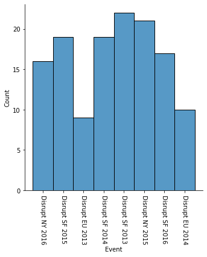

```python
fig = plt.figure(figsize = (15,5))
sns.displot(data=event_test_simp, x='Event');
plt.xticks(rotation=-90)
```

```python
event_test_simp['Funding'] = (event_test_simp['Funding']/1000000)
event_test_simp
```

|  | Funding | Event |
| --- | --- | --- |
| 3 | 1.000 | Disrupt NY 2016 |
| 13 | 1.000 | Disrupt SF 2015 |
| 16 | 11.600 | Disrupt SF 2015 |
| 42 | 8.300 | Disrupt EU 2013 |
| 46 | 12.300 | Disrupt SF 2015 |
| ... | ... | ... |
| 633 | 2.500 | Disrupt NY 2015 |
| 634 | 2.000 | Disrupt SF 2015 |
| 635 | 0.050 | Disrupt NY 2015 |
| 642 | 0.028 | Disrupt SF 2014 |
| 660 | 3.400 | Disrupt SF 2013 |

133 rows × 2 columns

[output not shown]

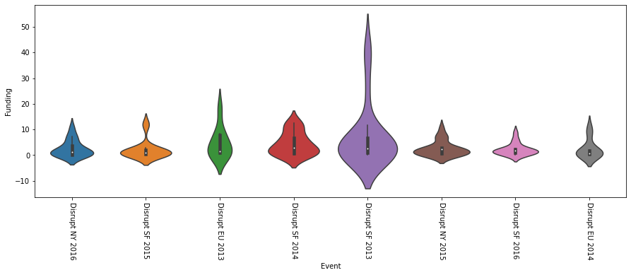

```python
fig = plt.figure(figsize = (15,5))
sns.violinplot(x='Event',y='Funding',data=event_test_simp,scale="count");
plt.xticks(rotation=-90)
```

# Write your observations

on improvements or suggestions on quality, quantity, variety, velocity, veracity etc. on the data points collected to perform a better data analysis.

Based on the analysis of the dataset interms of visualization and statistics analysis the following points can be included: 1.Lot of missing values were present in the dataframe especially in the fund raised by the company (214) followed by company's product(6). The missing values can be avoided by effective analysing of dataset. 2.Data regarding feasibility study and social impact of the product made by the company is missing as it is the one of the main criteria for deciding the result of the event. 3.Funds raised across different events could be more precise and fine tuned. 4. Events conducted can also be fine tuned with respect to cities or country where it was conducted, and the year when it was conducted by creating seperate attributes for the same. 5. Results of the events can also be made with seperate attributes indicating 'Winner', 'Runner-Up' and so on. 6. Volume (how many) and information about the companies participated for the event on the particular year and its close competators could be included as a seperate attributes for effective analysis.